# Aside

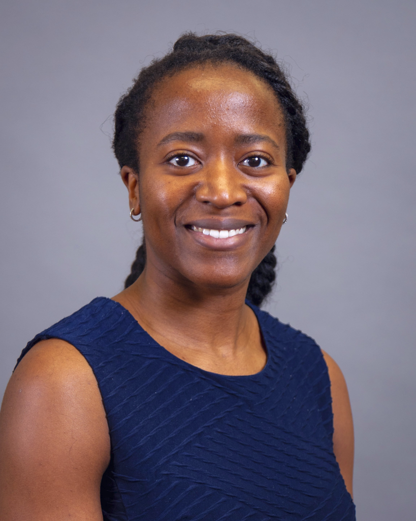

[Download PDF of this CV](https://joellesophya.github.io/cv/cv2025.pdf)

## Contact

- Chicago, IL
- US Citizen
- joelle.mbatchou@gmail.com
- (773)599-2825
- joellembatchou
- linkedin.com/in/jmbatchou
- github.com/joellembatchou
- joellesophya.github.io

## Technical Skills

R

C/C++

Bash

WDL

docker

Jupyter

Python

## Disclaimer

Last updated on 2025-06-05.

# Main

## Joelle Mbatchou Ph.D.

- Proficient and innovative researcher with 10+ years of research experience in developing cutting-edge methods to help improve understanding of genetic variation and its relationship to human health and disease
- Avid and charismatic learner who continuously strives for excellence by always meeting deadlines, providing timely solutions, and staying attentive to new developments in the field
- Eager to assist biotech companies in discovering novel targets and indications by building scalable and efficient association analysis tools and pipelines
- Developed a C++ tool which decreased computation costs at the Regeneron Genetics Center by over 50X
- Top Skills: Analytical, Highly Proficient in C++ and R, Pipeline development with WDL & docker, Project Management

## Education

### PhD., Statistics

University of Chicago

Chicago, IL

2019

### BSc Biology & Mathematical Sciences

DePaul University

Chicago, IL

2011

## Industry Experience

### Senior Manager, Statistical Genetics

Regeneron Genetics Center

Tarrytown, New York

Current - 2024

- Leading and mentoring a team member in the development of an analytical pipeline for time-to-event data.
- Develop machine learning methods to integrate functional annotations into rare variant association analyses using exome sequencing data.

### Manager, Statistical Genetics

Regeneron Genetics Center

Tarrytown, New York

2023 - 2022

- Routinely carry out statistical analyses using cloud-based computing platforms on large-scale and high-dimensional human genetics datasets containing millions of genetic variants and 100,000s of individuals
- Develop statistical methods and computational tools geared for large-scale genetic and genomics studies
- Build WDL pipelines for data sets with 100,000s of individuals from whole-exome and whole-genome sequencing data

### Senior Statistical Geneticist

Regeneron Genetics Center

Tarrytown, New York

2021 - 2019

- Developed a computational efficient whole genome regression method REGENIE for large-scale genetic association analyses which can be more than 100x faster than current state-of-the-art methods and can handle population structure and imbalanced binary traits
- Implemented REGENIE into a C++ software which was publicly released on Github
- Published the REGENIE method as first author in Nature Genetics where it was applied to UK Biobank data (>100 phenotypes, >400K individuals and >10M genetic variants).

## Research Experience

### Graduate Student Researcher

Department of Statistics

University of Chicago

2019 - 2013

- Developed a computationally fast method JASPER to assess significance for a general class of association tests, including tests for high dimensional phenotypes and gene-based tests, adjusting for population structure and family relatedness
- Designed a permutation-based testing procedure BRASS for assessing significance with binary traits in structured samples for association tests with unknown exact/asymptotic distributions.
- Built C/C++ software to evaluate JASPER and BRASS through simulation studies & real data applications.

## Teaching Experience

### Instructor

Summer Institute in Statistical Genetics

University of Washington/Georgia Institute of Technology

Current - 2022

- Taught the association mapping module on genome-wide association studies and sequencing (120 students)
- Designed coursework as well as hands-on practical exercises using software such as PLINK, REGENIE and R packages GWASTools and bigsnpr.
- Built a website to host the course materials using workflowr R package.

### Teaching Assistant

Department of Statistics

University of Chicago

2019 - 2012

- Assisted in undergraduate courses: Statistical Methods and Applications, Statistical Models/Methods, Applied Regression Analysis and Analysis of Categorical Data
- Created introductory material for R and STATA through weekly computer sessions
- Organized weekly office hours where students expanded their understanding of course materials

### Course Instructor

Department of Statistics

University of Chicago

2018

- Taught an introductory course on statistical methods (STAT 234: Statistical Models/Methods).
- Designed course materials and delivered bi-weekly lectures to a class of 36 students.
- Assisted students in office hours with learning statistical concepts as well as R programming skills.

### Statistics Collaborative Learning Team Leader

Department of Statistics

University of Chicago

2017 - 2016

- Facilitated the design of a new program based on collaborative learning.
- Designed practical exercises based on class mateirals and supervised weekly hands-on workshops for students.

## Awards

### [Selected as one of 35 innovators under 35](https://www.technologyreview.com/innovator/joelle-mbatchou/)

MIT Technology Review

N/A

2022

### [Selected as one of 17 Rising Stars in Health Tech](https://www.fiercehealthcare.com/health-tech/rising-stars-health-tech)

Fierce Health Care

N/A

2022

### Selected for Reviewers’ Choice (top 10% scoring abstracts)

American Society of Human Genetics

N/A

2021

### Department of Education GAANN Fellowship Recipient

University of Chicago

N/A

2013

### Departmental Award for Outstanding Performance in Organic Chemistry

DePaul University

N/A

2010

## Publications

### [JASPER: fast, powerful, multitrait association testing in structured samples gives insight on pleiotropy in gene expression](https://doi.org/10.1016/j.ajhg.2024.06.010)

American Journal of Human Genetics

N/A

2024

- Authors: **Mbatchou, J.** & McPeek, M. S.

### [Joint testing of rare variant burden scores using non-negative least squares](https://doi.org/10.1016/j.ajhg.2024.08.021)

American Journal of Human Genetics

N/A

2024

- Authors: Ziyatdinov, A., **Mbatchou, J.**, Marcketta, A., Backman, J., Gaynor, S., et al.

### [Genetic risk factors for COVID-19 and influenza are largely distinct](https://doi.org/10.1038/s41588-024-01844-1)

Nature Genetics

N/A

2024

- Authors: Kosmicki, J. A., Marcketta, A., Sharma, D., Di Gioia, S. A., Batista, S., Yang, X.-M., Tzoneva, G., Martinez, H., Sidore, C., Kessler, M. D., Horowitz, J. E., Roberts, G. H. L., Justice, A. E., Banerjee, N., Coignet, M. V., Leader, J. B., Park, D. S., Lanche, R., Maxwell, E., Knight, S. C., Bai, X., Guturu, H., Baltzell, A., Girshick, A. R., McCurdy, S. R., Partha, R., Mansfield, A. J., Turissini, D. A., Zhang, M., **Mbatchou, J.**, et al.

### [Genotyping, sequencing and analysis of 140,000 adults from Mexico City](https://doi.org/10.1038/s41586-023-06595-3)

Nature

N/A

2023

- Authors: Ziyatdinov, A., Torres, J., Alegre-Díaz, J., Backman, J., **Mbatchou, J.**, Turner, M., et al.

### [BRASS: Permutation methods for binary traits in genetic association studies with structured samples](https://doi.org/10.1371/journal.pgen.1011020)

PLoS Genetics

N/A

2023

- Authors: **Mbatchou, J.**, Abney, M., & McPeek, M. S.

### [Rare coding variants in CHRNB2 reduce the likelihood of smoking](https://doi.org/10.1038/s41588-023-01417-8)

Nature Genetics

N/A

2023

- Authors: Rajagopal, V. M., Watanabe, K., **Mbatchou, J.**, Ayer, A., Quon, P., et al.

### [Common and rare variant associations with clonal haematopoiesis phenotypes.](https://doi.org/10.1038/s41586-022-05448-9)

Nature

N/A

2022

- Authors: Kessler, M. D., Damask, A., O’Keeffe, S., Banerjee, N., Li, D., Watanabe, K., Marketta, A., Van Meter, M., Semrau, S., Horowitz, J., Tang, J., Kosmicki, J. A., Rajagopal, V. M., Zou, Y., Houvras, Y., Ghosh, A., Gillies, C., **Mbatchou, J.**, et al.

### [Genome-wide analysis provides genetic evidence that ACE2 influences COVID-19 risk and yields risk scores associated with severe disease.](https://doi.org/10.1038/s41588-021-01006-7)

Nature Genetics

N/A

2022

- Authors: Horowitz, J. E., Kosmicki, J. A., Damask, A., Sharma, D., Roberts, G. H. L., Justice, A. E., Banerjee, N., Coignet, M. V., Yadav, A., Leader, J. B., Marcketta, A., Park, D. S., Lanche, R., Maxwell, E., Knight, S. C., Bai, X., Guturu, H., Sun, D., Baltzell, A., Kury, F. S. P., Backman, J. D., Girshick, A. R., O’Dushlaine, C., McCurdy, S. R., Partha, R., Mansfield, A. J., Turissini, D. A., Li, A. H., Zhang, M., **Mbatchou, J.**, et al.

### [Germline Mutations in CIDEB and Protection against Liver Disease.](https://doi.org/10.1056/NEJMoa2117872)

New England Journal of Medicine

N/A

2022

- Authors: Verweij, N., Haas, M. E., Nielsen, J. B., Sosina, O. A., Kim, M., Akbari, P., De, T., Hindy, G., Bovijn, J., Persaud, T., Miloscio, L., Germino, M., Panagis, L., Watanabe, K., **Mbatchou, J.**, et al.

### [Sequencing of 640,000 exomes identifies GPR75 variants associated with protection from obesity.](https://doi.org/10.1126/science.abf8683)

Science

N/A

2021

- Authors: Akbari, P., Gilani, A., Sosina, O., Kosmicki, J. A., Khrimian, L., Fang, Y. Y., Persaud, T., Garcia, V., Sun, D., Li, A., **Mbatchou, J.**, et al.

### [Exome sequencing and analysis of 454,787 UK Biobank participants.](https://doi.org/10.1038/s41586-021-04103-z)

Nature

N/A

2021

- Authors: Backman, J. D., Li, A. H., Marcketta, A., Sun, D., **Mbatchou, J.**, et al.

### [Pan-ancestry exome-wide association analyses of COVID-19 outcomes in 586,157 individuals.](https://doi.org/10.1016/j.ajhg.2021.05.017)

American Journal of Human Genetics

N/A

2021

- Authors: Kosmicki, J. A., Horowitz, J. E., Banerjee, N., Lanche, R., Marcketta, A., Maxwell, E., Bai, X., Sun, D., Backman, J. D., Sharma, D., Kury, F. S. P., Kang, H. M., O’Dushlaine, C., Yadav, A., Mansfield, A. J., Li, A. H., Watanabe, K., Gurski, L., McCarthy, S. E., Locke, A. E., Khalid, S., O’Keeffe, S., **Mbatchou, J.**, et al.

### [Computationally efficient whole-genome regression for quantitative and binary traits.](https://doi.org/10.1038/s41588-021-00870-7)

Nature Genetics

N/A

2021

- Authors: **Mbatchou, J.**, Barnard, L., Backman, J., Marcketta, A., Kosmicki, J. A., Ziyatdinov, et al.

### [Retrospective Association Analysis of Binary Traits: Overcoming Some Limitations of the Additive Polygenic Model.](https://doi.org/10.1159/000446957)

Human Heredity

N/A

2015

- Authors: Jiang, D., **Mbatchou, J.** & McPeek, M. S.

### New insights into relationships of lichen-forming Dothideomycetes.

Fungal Diversity

N/A

2011

- Authors: Nelsen, M. P., Lücking, R., **Mbatchou, J. S.**, Andrew, C. J., Spielmann, A. A. & Lumbsch, H. T.

### Heiomasia, a new genus in the lichen-forming family Graphidaceae (Ascomycota: Lecanoromycetes: Ostropales) with disjunct distribution in Southeastern North America and Southeast Asia.

The Bryologist

N/A

2010

- Authors: Nelsen, M. P., Lücking, R., Plata, E. R. & **Mbatchou, J. S.**

### A class-wide phylogenetic assessment of Dothideomycetes.

Studies in Mycology

N/A

2009

- Authors: Schoch, C. L., Crous, P. W., Groenewald, J. Z., Boehm, E. W., Burgess, T. I., Gruyter, J. de, Hoog, G. S. de, Dixon, L. J., Grube, M., Gueidan, C., Harada, Y., Hatakeyama, S., Hirayama, K., Hosoya, T., Huhndorf, S. M., Hyde, K. D., Jones, E. B., Kohlmeyer, J., Kruys, A., Li, Y. M., Lucking, R., Lumbsch, H. T., Marvanova, L., **Mbatchou, J. S.**, et al.

## Professional activities

### Manuscript reviewer

Nature Genetics, Genetic Epidemiology, Bioinformatics.

N/A

N/A

## Oral presentations and posters

### Using protein language model annotations to improve the power of exome-wide association studies

The American Society of Human Genetics Annual Meeting

N/A

2023

- Poster presentation

### Powerful gene-based testing for exome-wide association studies

University of Washington Statistical Genetics Symposium

N/A

2023

- Invited Talk

### REGENIE v3: more efficient analysis of rare genetic variation with an extended set of gene-based tests

The American Society of Human Genetics Annual Meeting

N/A

2022

- Poster presentation

### Computationally efficient whole-genome regression framework for association analyses in large-scale biobanks.

International Common Disease Alliance

N/A

2022

- Virtual Scientific Plenary

### Gene-burden tests, gene-environment interactions and time-to-event data analysis within an efficient whole genome regression framework for large-scale biobanks.

The American Society of Human Genetics Annual Meeting

N/A

2021

- Poster presentation

### Fast and robust methods to detect gene-environment interactions in large-scale biobanks.

International Genetic Epidemiology Society Conference

N/A

2021

- Lightning talk

### Computationally efficient whole-genome regression for quantitative and binary traits.

The American Society of Human Genetics Annual Meeting

N/A

2020

- Platform talk

### A generalized permutation testing method for binary trait association in structured samples.

The American Society of Human Genetics Annual Meeting

N/A

2017

- Poster presentation

### Genetic association analysis of binary traits in structured samples.

Eastern North American Region Spring Meeting

N/A

2017

- Poster presentation